# Coconut crab (*Birgus latro*) monitoring in Picard

# Key findings

- Aldabra might have, along with Christmas Island, the only significant *Birgus latro* population worldwide. However, Aldabra might be one of the last safe refigia for this species, as the status of the Christmass Island population is of concern and their numbers on decline.
- Overall *Birgus latro* densities in Picard transects is 35.4 ± 1.69 ind./ha. This density have been stable over the last 9 years, and evidence for population increase or decline was not found.
- We demonstrate substantial spatial and temporal heterogeneity on observed denstities, which when compounded with the cryptic nature of this species, call into question previous density estimates for this species elsewhere.
- As observed in most studied populations worldwide, Aldabra’s population is sexually dymorphic, with males being substantially larger than females.
- At the relatively small spatial scale of this study, sex ratio appears to be extremely biased towards males (76% of encountered individuals). Only one studied population in New Caledonia has been found to have lower male to female ratio than the one found in Picard.
- Based on the encounters with ovigerous females, the reproductive season occurs with most likelyhood between December and March, at the beginning of the rainy season. Moreover, we found signs of synchrony with the moon cycle as ovigerous females were mostly encountered during surveys performed close to new moon. This synchrony is likely related to the timing of spawning, nevertheless, it can also be related to timing egg extrussion.
- Competitive dominance by large males and female habitat requirements seems to underpin spatial and temporal dynamics observed on *B. latro* population structure (this still needs to be explicitly tested prior to publication).
- From February to May, the overall number of crabs observed is higher than average. This rise is largely due to an increase on the number of males. During this time, large dominant males favour areas further from shore, presumably of higher quality, while females and smaller males are mostly encounterered in near-shore habitats. Afterwards, roughly from June to December, the overall number of crabs is lower than average. Again, this is largely due to a decreasse on the number of males, particularly of large ones, which seem to preferentially undergo moulting during the drier months of the year. During this period, in stark contrast with the lower male density, female counts increasse on the second half of the year both in the coastal and inshore areas, likely oportunistically filling the available niche left by dominant males. Nevertheless, the observed affinity of females to the coast is not likely to be an exclusive result of male dominance as large females also preferentially occupied coastal habitats during the dry season, when large dominant males are less likely to be encountered. Female densities peak between September to December which coincides with an period in which males of sexually active sizes are commonly encountered.
- The timing between mating and egg extrusion is unknown. As female individuals don’t posess seminal receptacle, it is believed that egg extrusion occurss shortly after mating. However the dataset offers evidence, albeit somewhat tenuous, that mating might potentially up to two months before extrusion.

# Methods

*B. latro* populations have been proposed to be, at least partially, structured by the distance to the shore (Chauvet and Kadiri-Jan 1999). Therefore, two roughly pararell transects were established at different distances from the shore. A coastal transect was composed by 27 lineal sections separated from the shore by distances ranging between 1 and 26m from the shore, while an inshore transect was composed by 39 lineal sections with distances ranging between 38 and 177m. Coastal and inshore transects had total length of 1.4 and 1.8km respectively while the length of sections within them ranged between 35 and 96m.

Regular surveys in these two transects were performed simultaneously after sunset, roughly every two weeks between January 2007 and May 2016 (Supplementary Material). In each survey we recorded all individuals encountered within five meters of the mid transect line. For each encounter, we recorded the thoracic length, the sex, an estimate of the distance to the middle line, an index of pleonal (abdominal) expansion (see section below for details), and in the case of the females wether they were carrying eggs or not. In addition, *B. latro* behaviour has been hypothesised to be influenced by humidity and the phase of the moon (Sato and Yoseda 2009; Drew et al. 2010). Therefore, in each survey we recorded wether soil was moist (due to ongoing or previous rain) or not, and back calculated the phase of the moon during the survey using the R package `oce` (Kelley and Richards 2015). The phase of the moon was defined as a continuous variable from zero to one, with both extremes corresponding to new moon, 1/4 for fist quarter, 1/2 for full moon, and 3/4 for last quarter (Meeus 1982).

## Data analysis

### Population structure

#### Density

The density of *B. latro* during each survey was estimated using the the hierarchical distance sampling model of Royle, Dawson, and Bates (2004) implemented in the R package `unmarked` (Fiske and Chandler 2011). Briefly, within each survey and each transect’s lineal sections, we pooled the counts of encountered individuals in five distance categories: 0-1, 1-2, 2-3, 3-4, and 4-5m. We then used these counts to estimate the overall density during the survey and evaluated the impact that habitat composition had in both the detectability and abundance of *B. latro*.

Habitat composition was obtained using high resolution satellite imagery (details? references?). In each transect section we calculated the percentage of area occupied by eight different habitat types that could affect *B. latro* detectability and/or abundance. In decreassing order of area occupied these habitats were: open mixed scrub, exposed surface, standard mixes scrub, grasses, mangrove, sand, pemphis—densely branched bushes formed primarely by short *Pemphis acidula* trees, and ‘champignon’—an irregular coral limestone formation characteristic of Aldabra. To maximise differentiation between transect sites and reduce the dimensionality of the data, we then transformed the habitat composition percentages using a principal component analysis. Finally, we included the two components that explaining the largest proportion of the variance as covariates in our distance sampling model. Due to the large number of surveys, we used a fixed effects meta-analysis approach to ascertain the signifcancy of the covariates. We determined a covariate to significanlty affect detectability if its effect was be consistent over different surveys, and to significantly affect abundance if its effect was either consistent over surveys or variable but acording to the seasons. In each survey, we used the Akaike information criterion (AIC) to determine wether our detection process was better approximated by a half-normal, a negative exponential, a hazard-rate, or an uniform distribution function.

Next, we used a generalised additive model (GAM) to determine wether *B. latro* densities varied significantly *(i)* over the years, *(ii)* over the yearly cycle, and *(iii)* over the lunar cycle. Models were fitted using the R package `mgcv` (Wood 2006a), and the model parsimony was assessed by comparing their AIC values.

Although distance sampling provides an accurate indication of the crab density, the analysis of abundance patterns at finer spatial and temporal scale is not straighforward. Therefore, we used direct counts to further investigate *B. latro* population dynamics. This was possible because initial analysis indicated that crab detectability did not change over time and was not influenced by habitat composition (see Results section and Supplementary Information for details) and consequently direct counts provide an accurate index of crab abundance.

As stated before, proximity to shore, phase of the moon, and environmental factors (which are strongly determined by the seasons in Aldabra) may have an effect on *B. latro* relative abundances. Moreover these effects might be different for each sex due to different reproductive requirements. We therefore used a GAM to quantify the relative effect of the aforementioned variables on the counts of both male and female individuals. As it is plausible that environmental factors interact with habitat requirements, the tensor product interaction between day of the year and distance from shore was included in the model (Wood 2006b).

#### Sex ratio

Sex ratios have been found to be strongly squewed towards males in most studied *B. latro* populations (Drew et al. 2010). Sex rations were directly calculated from the individual counts. However, because of the potential relevance for reproduction, we also calculated the sex ratio that would be observed if only sexually mature individuals were included. Full sexual maturity was asumed based on individuals with a thoracic length smaller than 28mm (Fletcher, Brown, and Fielder 1990; Sato and Yoseda 2008). In addition, we used the models developed for individual counts to infer the effects that time of the year, distance from shore, and pahse of the moon may have on the sex ratio.

#### Size

Thoracic length is the most widely used body size parameter in *Birgus latro* allometry studies (Amesbury 1980; Anagnostou and Schubart 2014). Nevertheless, we confirmed the allometric relationship between thoracic length and weight in the Aldabra population. To do that we measured the thoracic length in 1567 indviduals and used the power law *w = al<sup>b</sup>* to relate it with weight, where *l* is the thoracic lengtht (in milimeters), *w* is the total weight (in grams), *a* corresponds to the proportionality coefficient, and *b* to the scaling exponent. The parameters *a* and *b* were calculated using an standarised major axis regression implemented in the R package `smatr` (Warton et al. 2006; Warton et al. 2012).

Sexual dimorphism, with males being in average larger than females, appears to be a pervasive characteristic of *B. latro* populations. As we found thoracic length to be a good indicator for weight in the local population we used it as an indicator of size to determine the differences between males and females. The difference was evaluated by visually inspecting the size distribution for both sexes and a t-test on the length meassurements. Furthermore, similar as for the counts, we used a set of GAMs to explore wether there were differences on the sizes of individuals encountered varied with respect to the distance from shore, the time of the year, or the lunar cycle. As before, competing models were compared using their AIC.

### Pleonal expansion

Pleonal (abdominal) expansion can be an indication of the moulting stage as recently moulted individuals will have a relativelly small abdomen for its size and individuals with a very swollen abdomen are likely to moult in the near future. Recently, pleonal expansion has also been unambiguolsly linked to the reproductive condition of females, as it can be indicative of gonad development (Sato and Yoseda 2009). During each encounter we registered the degree of pleonal expansion using a four-level categorical scale. In this scale 1 was assigned to individuals in which all tergal plates are touching each other or there is only a small gap between the most posterior tergal plate (first plate) and the next (second plate). An index of 2 was assigned to those in which the pleon was slightly swollen and the fleshy abdomen is visible between the frist and second plates, and somewhat visible between the second and third plate. An index of 3 was assigned if the pleon was swollen and the fleshy abdomen is clearly present between the first, second and third plates, and somewhat visible between the third and the fourth plate. Finally, an index of 4 indicates an strongly swollen pleon and the fleshy abdomen is visible between all tergal plates.

To understand wheter there is evidence of synchronous seasonal moulting, and to provide insight into the onset of reproductive season, we constructed two GAMs, one for each sex, in which the response was the index of pleonal expansion (treated as a numeric variable) and the predictor was the time of the year.

### Reproduction

To determine the reproductive season we constructed a GAM with a binomial error distribution in which the response variable was wether a female was seen carrying eggs during a survey transect or not. This method was prefered to model the counts of ovigerous females because of the large proportion of zeroes. As we were mostly concerned with the timing of the reproduction, we included only time of the year and phase of the moon as response variables.

# Results

In total, 281 surveys were performed over the study period. Effort was held relatively constant and 2.3 ± 0.99 (mean ± sd) surveys were performed each month. This led to a total of 8145 individual encounters.

### Population structure

#### Density

The two principal components of the habitat composition (which were included as covariates in our distance sampling models) explained 81% of the variance found among transect sections. The first componet, was strongly correlated with an increase on the area covered by open mixed scrub, but mainly with a decrease on percentage of exposed surface. The second component, was largely correlated with an increase of grass and with a decreasse of standard mixed scrub (Supplementary Information). These habitat differences, however, did not significantly affected the detectability or the abundances of *B. latro* (Supplementary Information). Overall, based on AIC values, the most parsimonuous models were those fitting a negative exponential function to the detection process.

We found *B. latro* density in our study area to vary between 3.2 and 189.4 individuals per hectare, with an overall average density of 35.4 ± 1.69 ind./ha (mean ± standard error). The overall density shows small variations over the years, but no long term trend is observable (Figure 1A). Similarly, we did not find a significant variation on density over the moon cycle (Supplementary Information). Contrastingly, we found important seasonal changes on abundance, being above average between February and June—with a clear peak on April, and below average for the rest of the year (Figure 1B).

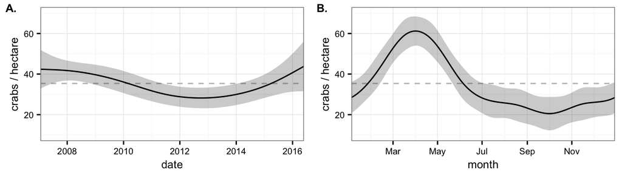

*Figure 1. Birgus latro density over (A) the years and over (B) the yearly cycle. The solid lines shows the values predicted by the GAM, gray while ribbons reprents the standard error.*

We found that the number of males and females encountered is strongly affected by the time of the year and the distance from shore. In general, male counts in each transect section seem to be the largest during the first half of the year. Within that period, between March-April, males concentrate afar from shore (Figure 2A). During the same period, when inshore counts are high for males, females counts are higher close to shore. In contrast, during the second half of the year when male counts are the lowest, female counts are at the highest both in coastal and inshore sections, particularly between October and November (Figure 2A).

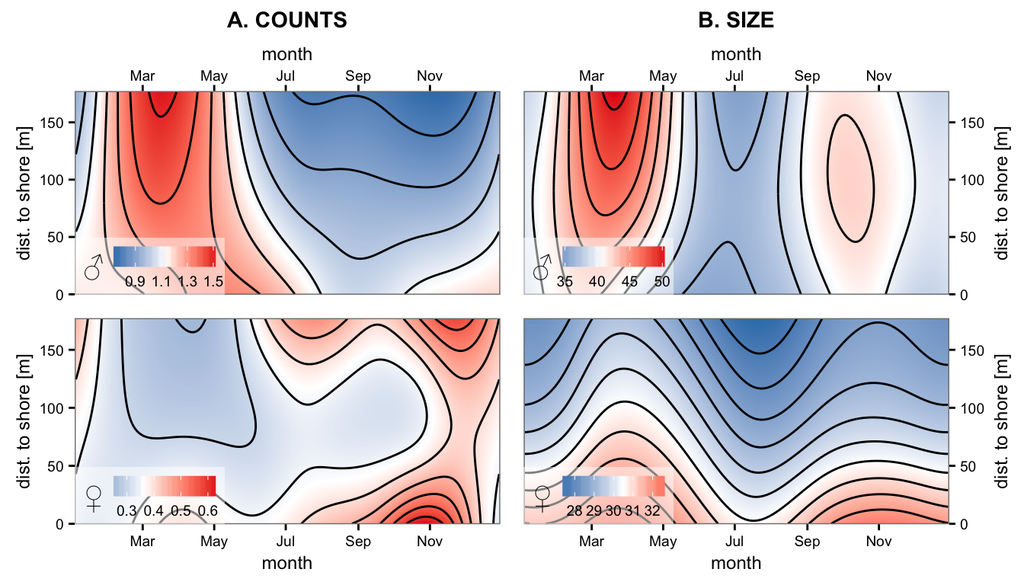

*Figure 2: Contour plots of the effect of time of the year and distance from shore on A) the counts and B) the size of both males (top panels) and females (bottom panels). In all panels, shades of red and blue indicate values larger and smaller than the average, respectively.*

Although moon phase did not affect the overall *B. latro* densities, it had distinct and complementary effects on males and females (Figure 3A). While females counts are the largest during periods of full moon, males are encountered in higher densities during new moon when the illuminated fraction of the moon at its minimum.

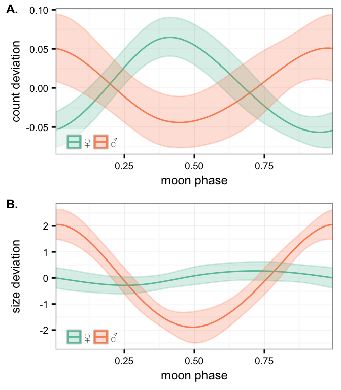

*Figure 3: effect of the phase of the moon on A) the count and B) the size of encountered females (green) and males (orange). The y-axes show the effect on the mean counts (0.36 females and 1.13 males) or the mean sizes (30.5mm thoracic length for females and 40.6mm for males) per transect section. The solid lines shows the values predicted by the GAM, gray while ribbons reprents the standard error. The phase of the moon is defined as 0 and 1 for new moon, 0.25 for fist quarter, 0.5 for full moon, and 0.75 for last quarter (Meeus 1982)*

#### Sex ratio

We found an overall ratio males:females of 1:0.32 (76% male), which increases to 1:0.23 (82% male) if only sexually mature individuals are included. As infered by the count models this ratio, however, shows significant temporal and spatial variation, ranging between 57% of individuals encountered being male during November in areas close to shore and 86% during March in areas far from shore.

#### Size

We found that indeed thoracic length and weight follow an allometric relationship. The standarised major axis estimated *a* = 0.0263 [0.023, 0.0301] (95% confidence interval) and *b* = 2.734 [2.698, 2.771]. The *R<sup>2</sup>* value for the relationship was 0.91. This high degree of correlation indicates that thoracic length can be adequately use to describe the size of *B. latro* in Aldabra.

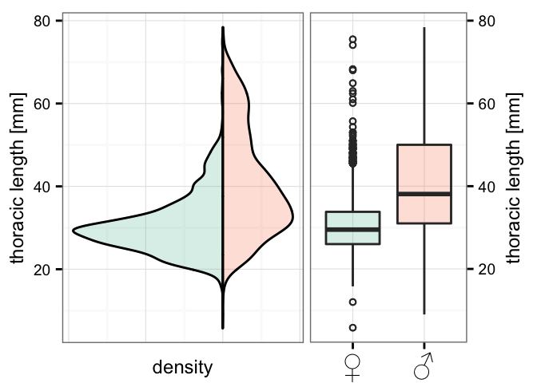

*Figure 4: Size distribution of Birgus Lastro in Aldabra. Green and orange female and male individuals respectively.*

### Pleonal expansion

We found that males over 30mm have exhibit a yearly cycle regarding the size of their pleon, with a clear peak on April-May (Figure 5). In contrast, females encountered on November have the largest pleon. In addition, females show an additional less conspicuous peak of pleon expansion between May and July (Figure 5).

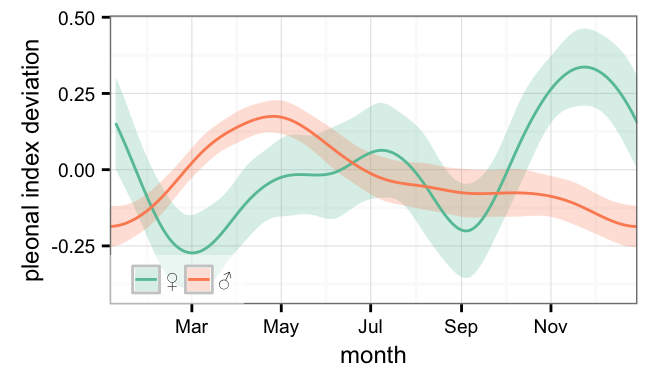

*Figure 5: Effect of time of the year on the mean pleon size for females (green) and males (orange). Pleon size was estimated using an index between 1 and 4. An index of 1 indicates that all tergal plates are touching each other of there is only a small gap between the most posterior tergal plate and the next. An index of 4 indicates an strongly swollen abdomen and all tergal plates are divided by thick gaps.*

### Reproduction

During the monitoring period, few females (14 out of 2071 individuals in 12 out of 438 transect surveys) were ovigerous. Nevertheless these observations consistently pointed out to a reproductive season between December and March with an increassed probability to encounter females carrying eggs just before new moon (Figure 6).

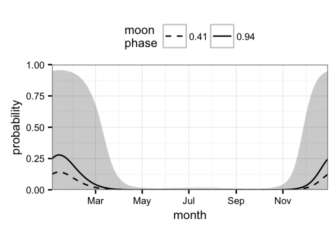

*Figure 6: Probability of encountering an ovigerous female during a survey. The solid line and dashed line correspond to the maximum and minimum encounter probability during the moon cycle respectively. A moon phase of 0.41 corresponds to about three days before full moon and 0.94 to around two days before new moon (Meeus 1982). Grey ribbon indicates confidence interval of the mean probability across the year.*

# Conclusions & recomendations

Despite limitations on the design of the surveys, the long term monitoring of *Birgus latro* on Picard has provided fundamental insight into the ecology of this species. Nevertheless, appart from the long term recording of local densities, continuing this monitoring on its current form is not reccomended as it unlikely to offer additional insight. Therefore, it’s suggested to redesign the monitoring so that field methods for the obtention of population parameters pertinent to adaptive management are optimised.

The fully protected status of *B. latro* in Aldabra, makes it possible to simplify management tasks, as improved understanding of its ecology, although highly desirable, is not imperative. However, SIF and its infrastructure in Aldabra, perhaps the last sanctuary for this species worldwide, is in a privileged position to unravel long held questions of this species. Answering these questions can provide potentially important lessons for other managed and unmanaged populations elsewhere. Although some of these questions are likelt to require dedicated efforts and resources, perhaps in collaboration with external universities, others can be attempted to be answered while fulfulling SIF’s core mission. Specifically, in order of priority, I provide the following reccomendations (open to discussion, please):

# References

Amesbury, Steven S. 1980. “Biological Studies on the Coconut Crab (Birgus Latro) in the Mariana Islands.” 17.

Anagnostou, Christiana, and Christoph D Schubart. 2014. “Morphometric characterisation of a population of adult coconut crabs Birgus latro (Decapoda: Anomura: Coenobitidae) from Christmas Island in the Indian Ocean.” *Raffles Bulletin of Zoology*, no. 30: 136–49.

Chauvet, C., and T. Kadiri-Jan. 1999. “Assessment of an unexploited population of coconut crabs, Birgus latro (Linne, 1767) on Taiaro atoll (Tuamotu archipelago, French Polynesia).” *Coral Reefs* 18 (3): 297–99. doi:10.1007/s003380050198.

Drew, M. M., S. Harzsch, M. Stensmyr, S. Erland, and B. S. Hansson. 2010. “A review of the biology and ecology of the Robber Crab, Birgus latro (Linnaeus, 1767) (Anomura: Coenobitidae).” *Zoologischer Anzeiger - A Journal of Comparative Zoology* 249 (1). Elsevier: 45–67. doi:10.1016/j.jcz.2010.03.001.

Fiske, I., and R. Chandler. 2011. “‘unmarked’: an R package for Fitting Hierarchichal Models of Wildlife Occurence and Abundance.” *Journal of Statistical Software* 43 (10): 1–23. doi:10.18637/jss.v043.i10.

Fletcher, W J, I W Brown, and D R Fielder. 1990. “Growth of the coconut crab Birgus latro in Vanuatu.” *Journal of Experimental Marine Biology and Ecology* 141: 63–78.

Kelley, Dan, and Clark Richards. 2015. *oce: Analysis of Oceanographic Data*. http://cran.r-project.org/package=oce.

Meeus, Jean. 1982. *Astronomical formulae for calculators*. 2nd ed. Richmond: Willmann-Bell,

Royle, J. Andrew, Deanna K. Dawson, and Scott Bates. 2004. “Modeling abundance effects in distance sampling.” *Ecology* 85 (6): 1591–7. doi:10.1890/03-3127.

Sato, Taku, and Kenzo Yoseda. 2008. “Reproductive season and female maturity size of coconut crab birgus latro on hatoma island, southern japan.” *Fisheries Science* 74 (6): 1277–82. doi:10.1111/j.1444-2906.2008.01652.x.

———. 2009. “Prediction of timing of mating and egg extrusion in the coconut crab birgus latro judged from female pleonal expansion.” *Fisheries Science* 75 (3): 641–48. doi:10.1007/s12562-009-0093-1.

Warton, David, Remko A Duursma, Daniel S Falster, and Sara Taskinen. 2012. “smatr 3- an R package for estimation and inference about allometric lines.” *Methods in Ecology and Evolution* 3 (2): 257–59. doi:10.1111/j.2041-210X.2011.00153.x.

Warton, David, Iian J Wright, Daniel S Falster, and Mark Westoby. 2006. “Bivariate line-fitting methods for allometry.” *Biological Reviews* 81: 259–91. doi:10.1017/S1464793106007007.

Wood, Simon N. 2006a. *Generalized additive models: an introduction with R*. CRC press.

———. 2006b. “Low-Rank Scale-Invariant Tensor Product Smooths for Generalized Additive Mixed Models.” *Biometrics* 62 (4): 1025–36. doi:10.1111/j.1541-0420.2006.00574.x.